# Pertemuan 2 - Anreg K1

Nabil Bintang Prayoga

2025-02-02

# Data

## Membaca Data

Jika data berupa csv, maka tidak perlu pemanggilan library(readxl) karena R sudah memiliki fungsi bawaan terhadap hal tersebut. Apabila file .csv pada software excel ditunjukkan dengan delimiter “**,**” maka dapat menggunakan fungsi `read.csv`, apabila delimiter berupa “**;**” maka dapat menggunakan fungsi `read.csv2`.

```r
library(readxl)

data <- read_excel("D:/KULIAHH/SEMESTER 6/ASPRAK ANREG/Pertemuan 2/Data Bintang.xlsx", sheet="Data")
head(data) #menampilkan sebagian data awal
```

```
## # A tibble: 6 × 14
##   Wilayah       PPM   IPM   RLS     JP   PBH   TBS   ASL   TPT  PDRB   JSM   UHH
##   <chr>       <dbl> <dbl> <dbl>  <dbl> <dbl> <dbl> <dbl> <dbl> <dbl> <dbl> <dbl>
## 1 Sumba Barat  27.2  65.2  6.92 152414 11.9   0.39  58.8  3.52 10199 12696  67.6
## 2 Sumba Timur  28.1  67.0  7.57 255498  5.87  0.3   61.8  2.21 16617 36053  65.8
## 3 Kupang       21.8  65.8  7.42 376837  6.17  1.18  76.4  3.22 13793 59622  65.6
## 4 Timor Teng…  25.2  63.6  6.97 474521  7.71  1.03  67.9  2.64 10953 57201  66.9
## 5 Timor Teng…  21.8  65.2  8.16 271277  3.98  0.45  80.6  1.96 11511 42634  67.6
## 6 Belu         14.3  63.8  7.39 231008  6.34  0.71  84.0  5.45 13997 45693  65.6
## # ℹ 2 more variables: LLR <dbl>, PKB <dbl>
```

## Menyesuaikan Peubah

Untuk mempermudah pemanggilan peubah pada saat eksplorasi dan analisis, jika pada file masih mengggunakan nama peubah yang panjang, maka bisa diganti dengan menggunakan fungsi `colnames()`. Kolom wilayah juga dapat dihapus dengan menggunakan syntax `namadata[,-1]` dengan -1 menunjukkan bahwa kolom pertama ingin dihapus.

```r
colnames(data) <- c("Wilayah", "Y", paste0("X", 1:12))
head(data)
```

```
## # A tibble: 6 × 14
##   Wilayah         Y    X1    X2     X3    X4    X5    X6    X7    X8    X9   X10
##   <chr>       <dbl> <dbl> <dbl>  <dbl> <dbl> <dbl> <dbl> <dbl> <dbl> <dbl> <dbl>
## 1 Sumba Barat  27.2  65.2  6.92 152414 11.9   0.39  58.8  3.52 10199 12696  67.6
## 2 Sumba Timur  28.1  67.0  7.57 255498  5.87  0.3   61.8  2.21 16617 36053  65.8
## 3 Kupang       21.8  65.8  7.42 376837  6.17  1.18  76.4  3.22 13793 59622  65.6
## 4 Timor Teng…  25.2  63.6  6.97 474521  7.71  1.03  67.9  2.64 10953 57201  66.9
## 5 Timor Teng…  21.8  65.2  8.16 271277  3.98  0.45  80.6  1.96 11511 42634  67.6
## 6 Belu         14.3  63.8  7.39 231008  6.34  0.71  84.0  5.45 13997 45693  65.6
## # ℹ 2 more variables: X11 <dbl>, X12 <dbl>
```

# Eksplorasi Data

```r
n <- nrow(data)
```

Saat ini terdapat 1 peubah Y dan 12 peubah X, misal ingin dilakukan eksplorasi dan analisis terkait peubah X6

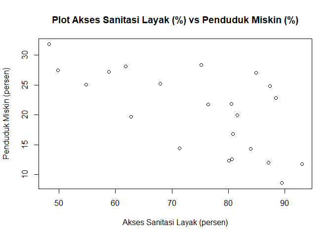

```r
plot(data$X6, data$Y,
     main = "Plot Akses Sanitasi Layak (%) vs Penduduk Miskin (%)",
     xlab = "Akses Sanitasi Layak (persen)",
     ylab = "Penduduk Miskin (persen)")
```

```r
summary(data$Y)
```

```
##    Min. 1st Qu.  Median    Mean 3rd Qu.    Max.
##    8.61   14.33   21.82   20.64   26.58   31.78
```

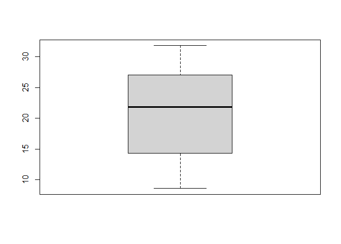

```r
boxplot(data$Y)
```

```r
summary(data$X6)
```

```
##    Min. 1st Qu.  Median    Mean 3rd Qu.    Max.
##   48.22   64.05   80.31   74.78   84.68   93.03
```

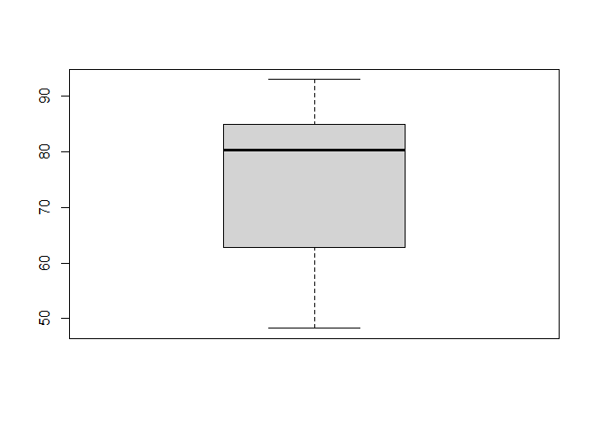

```r
boxplot(data$X6)
```

# Pembentukan Model

## Manual

### Koefisien Regresi

$\hat{y_i}=\hat{\beta_0}+\hat{\beta_1}x_i$, $i=1,2,...,n$

$\hat{\beta_0}=\bar{y}-\hat{\beta_1}\bar{x}$

```r
x <- data$X6
y <- data$Y
```

```r
b1 <- (sum(x*y)-sum(x)*sum(y)/n)/(sum(x^2)-(sum(x)^2/n))
b0 <- mean(y)-b1*mean(x)

cat("Koefisien b0:", b0, "\n")
```

```
## Koefisien b0: 44.76319
```

```r
cat("Koefisien b1:", b1, "\n")
```

```
## Koefisien b1: -0.3226753
```

### Standar Error Parameter Regresi

Standar error menunjukan seberapa besar ketidakpastian dalam estimasi koefisien

```r
galat <- y-(b0+b1*x)
ragam_galat <- sum(galat^2)/(n-2)

se_b0 <- sqrt(ragam_galat*(1/n+mean(x)^2/sum((x-mean(x))^2)))
se_b1 <- sqrt(ragam_galat/sum((x-mean(x))^2))

cat("Standar error b0:", se_b0, "\n")
```

```
## Standar error b0: 6.596295
```

```r
cat("Standar error b1:", se_b1, "\n")
```

```
## Standar error b1: 0.08689451
```

### Signifikansi Parameter (nilai-t)

Nilai ini menunjukkan tingkat signifikansi secara parsial dari setiap koefisien peubah berdasarkan nilai t dan probabilitas nilai p

```r
t_b0 <- b0/se_b0
t_b1 <- b1/se_b1
p_b0 <- 2*pt(-abs(t_b0 ),df<-n-2)
p_b1 <- 2*pt(-abs(t_b1 ),df<-n-2)

cat("Nilai t pada b0 adalah", t_b0, "dengan nilai p sebesar", p_b0, "\n")
```

```
## Nilai t pada b0 adalah 6.786112 dengan nilai p sebesar 1.341478e-06
```

```r
cat("Nilai t pada b1 adalah", t_b1, "dengan nilai p sebesar", p_b1, "\n")
```

```
## Nilai t pada b1 adalah -3.713414 dengan nilai p sebesar 0.001373623
```

Nilai p kurang dari alpha 0.05 untuk b0 maupun b1 sehingga signifikan pada taraf nyata 5%

### Koefisien Determinasi dan Penyesuaiannya

Pada analisis regresi linier sederhana, koefisien determinasi yang digunakan adalah *multiple R Squared*, sedangkan regresi linier berganda menggunakan *adjusted R Squared* yang disesuaikan dengan banyaknya peubah

```r
r <- (sum(x*y)-sum(x)*sum(y)/n)/
sqrt((sum(x^2)-(sum(x)^2/n))*(sum(y^2)-(sum(y)^2/n)))
Koef_det <- r^2
Koef_det
```

```
## [1] 0.4080992
```

```r
Adj_R2 <- 1-((1-Koef_det)*(n-1)/(n-1-1))
Adj_R2
```

```
## [1] 0.3785042
```

### Signifikansi Simultan (F)

Nilai ini menunjukkan signifikansi dan kebaikan model secara simultan (bersamaan seluruh peubah) yang menjelaskan model secara keseluruhan memiliki hubungan berarti antara X dan Y

```r
galat<-y-(b0+b1*x)

JKG <- sum((y - (b0+b1*x))^2)
JKReg <- sum(((b0+b1*x)- mean(y))^2)
JKT <- sum((y - mean(y))^2)
JKT <- JKReg+JKG

dbReg <- 1
dbg <- n-2
dbt <- n-1

(Fhit <- (JKReg/dbReg)/(JKG/dbg))
```

```
## [1] 13.78945
```

```r
(p_Fhit <- 1-pf(Fhit, dbReg, dbg, lower.tail <- F))
```

```
## [1] 0.001373623
```

Nilai p kurang dari alpha 0.05 sehingga secara simultan X dan Y saling memengaruhi

## Fungsi LM

Dalam penggunaan fungsi `lm()`, kita akan memperoleh secara langsung nilai-nilai pada pemodelan regresi dari data yang kita miliki. Hanya dengan mengeluarkan summary dan anova dari model yang terbentuk maka dapat diperoleh nilai parameter, signifikansinya, standar eror, koefisien determinasi hingga ukuran keragamannya.

```r
model <- lm(Y~X6, data <- data)
summary(model)
```

```
##
## Call:
## lm(formula = Y ~ X6, data = data <- data)
##
## Residuals:
##     Min      1Q  Median      3Q     Max
## -7.3300 -4.2971  0.0911  2.9552  9.6884
##
## Coefficients:
##             Estimate Std. Error t value Pr(>|t|)
## (Intercept) 44.76319    6.59629   6.786 1.34e-06 ***
## X6          -0.32268    0.08689  -3.713  0.00137 **
## ---
## Signif. codes:  0 '***' 0.001 '**' 0.01 '*' 0.05 '.' 0.1 ' ' 1
##
## Residual standard error: 5.333 on 20 degrees of freedom
## Multiple R-squared:  0.4081, Adjusted R-squared:  0.3785
## F-statistic: 13.79 on 1 and 20 DF,  p-value: 0.001374
```

```r
anova(model)
```

```
## Analysis of Variance Table
##
## Response: Y
##           Df Sum Sq Mean Sq F value   Pr(>F)
## X6         1 392.14  392.14  13.789 0.001374 **
## Residuals 20 568.75   28.44
## ---
## Signif. codes:  0 '***' 0.001 '**' 0.01 '*' 0.05 '.' 0.1 ' ' 1
```

Berdasarkan hasil diperoleh bahwa kedua cara valid dan memberikan hasil yang sama dalam membuat pemodelan regresi linear sederhana.

# Kesimpulan

Model yang terbentuk adalah sebagai berikut:

$$\hat{Y}=44.7632-0.3227X_6$$

dengan Y adalah persentase penduduk miskin dan X6 adalah persentase akses sanitasi layak.

Didapatkan nilai $\hat{\beta_0}=44.7632$ artinya nilai dugaan rataan persentase penduduk miskin ketika akses sanitasi layak bernilai 0 persen adalah 44.7632%, akan tetapi nilai 0 tidak ada dalam selang pengamatan persentase akses sanitasi layak sehingga $\hat{\beta_0}$ tidak dapat didefinisikan lebih lanjut

Nilai $\hat{\beta_1}=-0.3227$ artinya nilai dugaan perubahan dugaan rataan persentase penduduk miskin jika persentase akses sanitasi layak berubah satu persen adalah sebesar -0.3227%

Koefisien determinasi yang dihasilkan adalah 0.4081 atau 40.81% artinya keragaman persentase penduduk miskin yang dapat dijelaskan oleh persentase akses sanitasi layak adalah sebesar 40.81%, sisanya yaitu 59.19% dijelaskan oleh peubah lain yang tidak dimasukkan dalam model.